If you are a data junkie you should be on the Blockchain. The Blockchain is one of the richest sources data around. People are putting financial transactions on it, playing games, blogging, selling digital art …

We haven’t even scratched the surface of how the data can be used (for good and bad), but the best thing about it is its accessible to all. There is no better place to be if you are a budding Data Scientist or Researcher. **Forget about the Titanic or Iris data sets.** Come to Hive and see what data is available!

**Write your theses with real data from the Hive Blockchain!**

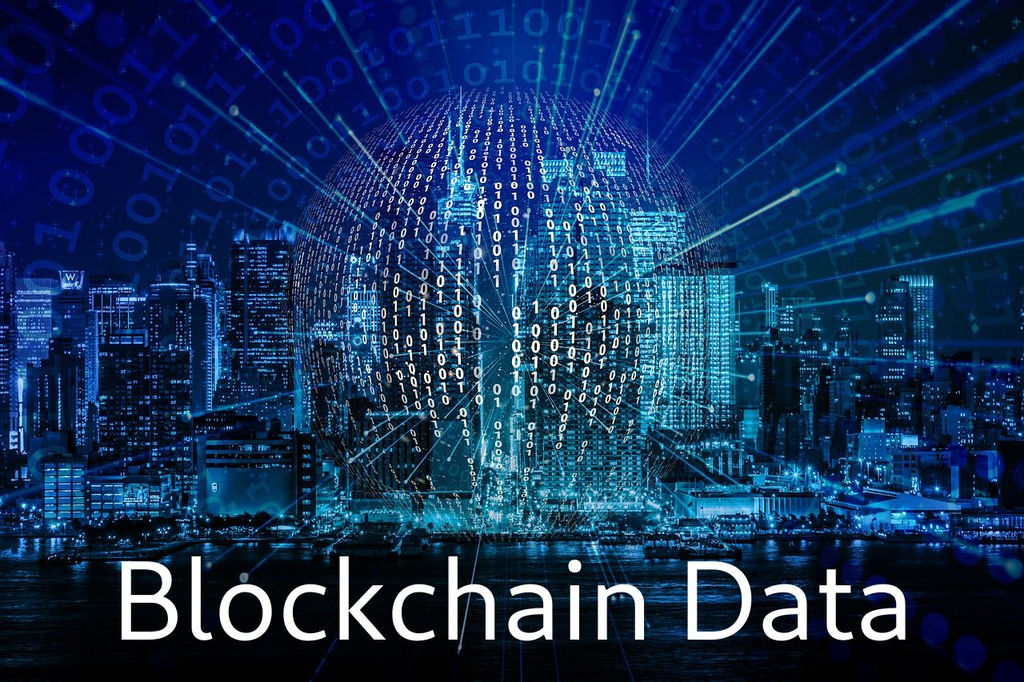

Blockchain Data.jpg

*… oh and did I mention you might even get paid for it if you give back to the blockchain!*

# Tutorial Series on Blockchain Data

This is the second post in a short series of posts to shine some light for the community and any budding Crypto Analysts to the rich data resource that is the Hive Blockchain. The series will use the R Programming Language. If you want to code along, I will share all the code I use but it’s aimed at more advanced users and introduces ideas and concepts for getting and visualising data, but really this is only the starting point.

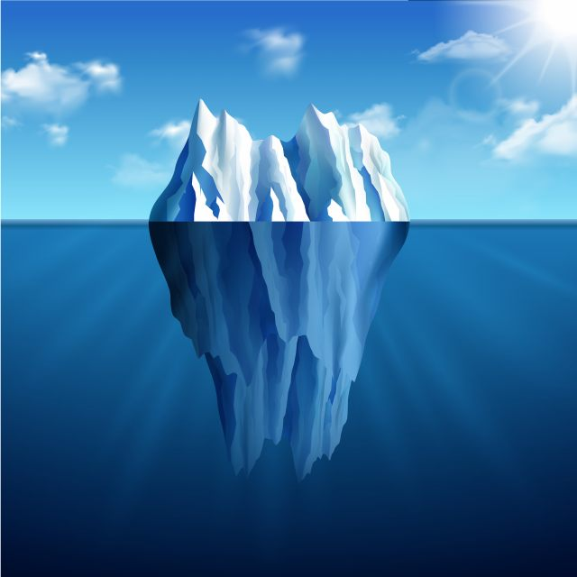

10951.jpg

As a long time practitioner of R I will also introduce some packages and tools along the way with a bit of history. All of the code will be available on Github.

# hiveRdata

This post covers some features of the hiveRdata package for accessing data directly from the Hive Blockhcain.

The goal of this package is to wrap some of the publicly available APIs in code so that a Data Analyst can focus on the Data Analysis rather than the Data Engineering and prep.

Common Data Access is wrapped in Functions, that are documeneted in the Package Help Pages, with Examples.

[figure not shown]

hiveRdata Help Pages.png

The Roadmap is to add functions here to the package as they are requested.

## Getting Started with hiveRdata

This is an addon package for R. It’s not on CRAN yet but I hope to get it up there in the new year, if there is interest. You can install it directly from my github. https://github.com/kharoof/hiveRdata

> install.packages(“devtools”)

> library(devtools)

> install_github(“kharoof/hiveRdata”)

## Blockchain Level Metrics

Now that you have it downloaded and instaled you can start using it. For some basic metrics it can be useful to query directly.

> accountCount()

This function Gets the count of the number of accounts on the Hive Blockchain

> getWitnesses()

This function returns a list of the top 100 witnesses as a data table.

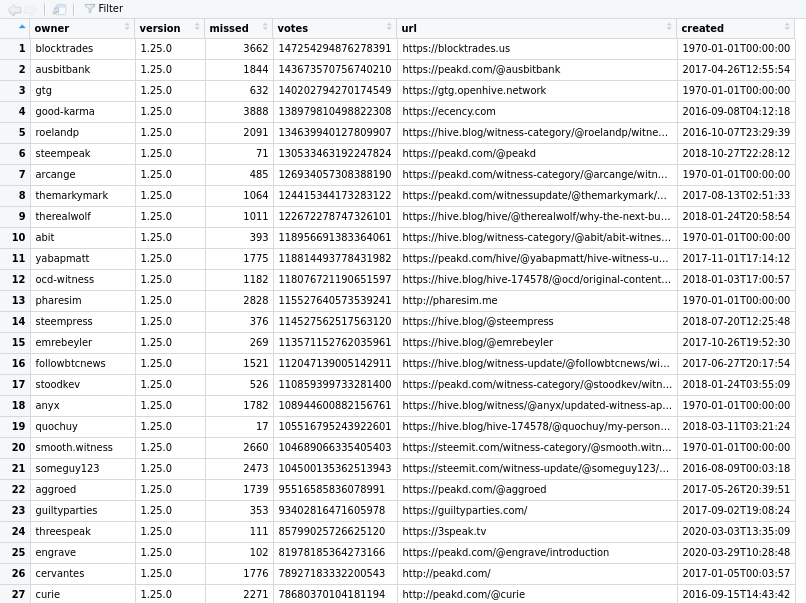

getWitnesses.png

## Granular Data

Beyond the High Level Metrics about the Blockchain you can also query more granular data at the post level or at the user level.

## Post Level

This is where you begin to process lots of data so these queries may take some time. To start with I will give an example of looking at the data in the Top Trending Posts.

> getTrending()

This returns the top 100 posts from the trending page with all the important data. The Text, Title, Tags …

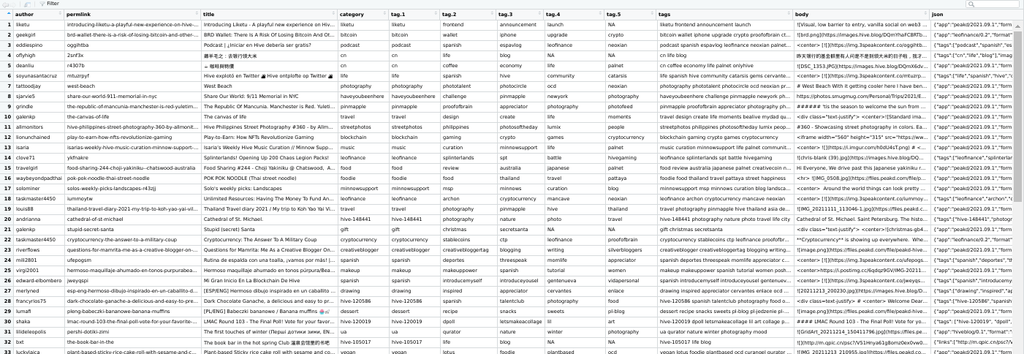

getTrending.png

Now any Data Analyst has at thier fingertips all the Text from all the Posts on the Trending Page.

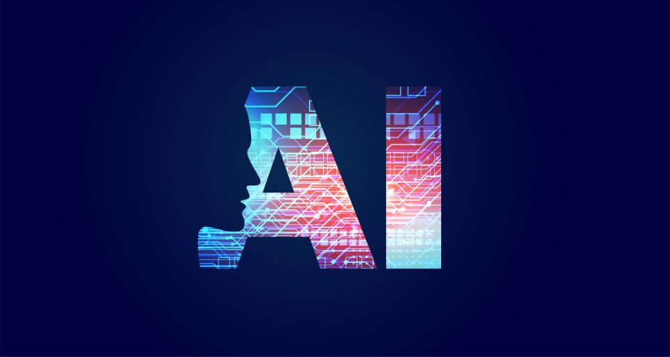

AI.jpg

As a Data Analyst or Scientist this is where it gets really exciting. at Your fingertip is real world data directly from teh Blockchain. Build Models, Visualisations, Dig in. There are no limits to the possibilities.

## Account Level

**What if you want to get details for a particular account?**

> getAccount(“eroche”)

Drill down to the user account @eroche

- When you have identified an account and want to pull out some metrics about the user. How many posts? How many comments?

## User Post Level

You may also wish to drill down to find a users posts.

I am going to use @culturevulture for this example

> getBlogPosts(“culturevulture”)

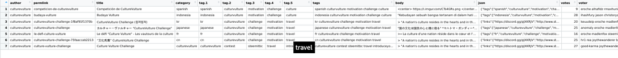

* This example shows data in the same structure as getTrending() but for a specific user.

## Next Steps

This package is a tool, it provides building blocks so that Analysts or Data Scientists can build data pipelines for their use cases with data from the Hive Blockchain. It’s early days and I will be adding most features. For large scale Data Crunching I would suggest you use another dapp from Hive such as @hivesql but for ad hoc analysis, or prototyping this might tool may be useful. It also does not depend on any service provider, you can specify the node. This is valuable if you want to remove dependencies from your analytics or access data from different sources.

# Upcoming Posts

# Previous Posts

## Write your Thesis with Real Data

The title of the post alludes to how you can make projects or demonstrations real with real data from the Blockchain. Forget about dull generic work with simple clean unimaginative data. If you are looking for something original use the blockchain. * In the comments please share some ideas of where you can swap out standard common datasets with real world Blockchain Datasets. https://hive.blog/hive-133987/@eroche/write-your-theses-with-real-data-from-the-hive-blockchain

# R 101 Series - For people begining with R

- https://hive.blog/@eroche/introduction-to-r
- https://hive.blog/@eroche/finding-your-way-around-r
- https://hive.blog/@eroche/scraping-web-data-with-r
- https://hive.blog/@eroche/data-wrangling-with-r
- https://hive.blog/@eroche/time-series-with-r

# Github for Code and Packages

**Please give me a Star on Github if you liked this post.** https://github.com/kharoof/

# Credits

[Background vector created by starline - www.freepik.com](https://www.freepik.com/vectors/background) [Winter vector created by macrovector - www.freepik.com](https://www.freepik.com/vectors/winter)